# Using haploR, an R package for querying HaploReg, RegulomeDB and LDlink

Ilya Y. Zhbannikov

Tue Jul 31 11:01:11 2018

## Overview

HaploReg (https://pubs.broadinstitute.org/mammals/haploreg/haploreg.php) (Ward and Kellis 2011), RegulomeDB (http://www.regulomedb.org) (Boyle et al. 2012), and LDlink (https://analysistools.nci.nih.gov/LDlink/) (Machiela and Chanock 2015) are web-based tools that extract biological information such as eQTL, LD, LD matrices, motifs, etc. from large genomic projects such as ENCODE, the 1000 Genomes Project, Roadmap Epigenomics Project and others. This is sometimes called “post stage GWAS” analysis.

The R-package *haploR* was developed to query those tools (HaploReg, RegulomeDB, LDlink) directly from *R* in order to facilitate high-throughput genomic data analysis. Below we provide several examples that show how to work with this package.

Note: you must have a stable Internet connection to use this package.

Contact: ilya.zhbannikov@duke.edu for questions of usage the *haploR* or any other issues.

### Motivation and typical analysis workflow

This package was inspired by the fact that many web-based post stage GWAS databases do not have Application Programing Interface (API) and, therefore, do not allow users to query them remotedly from R environment. In our research we used HaploReg and RegulomeDB web databases. These very useful web databases show information about linkage disequilibrium of query variants and variants which are in LD with them, expression quantitative trait loci (eQTL), motifs changed and other useful information. However, it is not easy to include this information into streamlined workflow since those tools also not offer API.

We developed a custom analysis pipeline which prepares data, performs genome-wide association (GWA) analysis and presents results in a user-friendly format. Results include a list of genetic variants (also known as ‘SNP’ or single nucleotide polymorphism), their corresponding *p*-values, phenotypes (traits) tested and other meta-information such as LD, alternative allele, minor allele frequency, motifs changed, etc. Of course, we could go throught the list of SNPs having genome-wide significant *p*-values (1e-8) and submit each of those SNPs to web-based tools manually, one-by-one, but it is time-consuming process and will not be fully automatic (which ruins one of the pipeline’s paradigms). This is especially difficult if the web site does not offer downloading results.

Therefore, we developed *haploR*, a user-friendly R package that connects to the web tool from R environment with methods POST/GET and downloads results in a suitable R format. This package siginificantly saved our time in developing reporting system for our internal genomic analysis pipeline and now we would like to present *haploR* to the research community.

Example of typical analysis workflow is shown below.

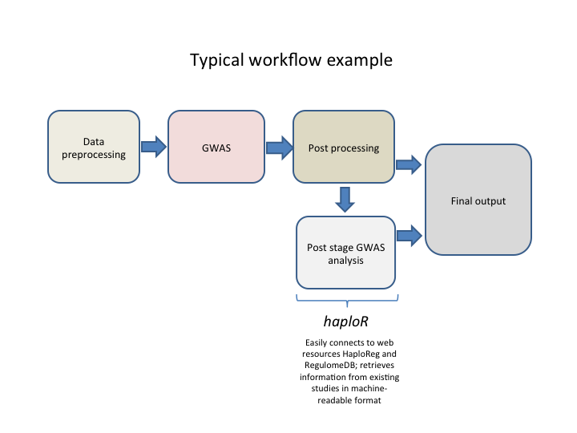

Typical analysis workflow

- Data preprocessing stage usually consists of basic cleaning operations (sex inconsistencies check, filtering by MAF, missing genotype rate), format conversion, population stratification, creating temporaty files, etc.
- Genome-wide association study (GWAS). This Includes testing hyphotesis on correlation between phenotype and genotype. Usually in form of linear or logistic regression but can be quite sophisticated especially for rare variants.
- Postprocessing usually includes summarizing results in tables, creating graphics (Manhattan plot, QQ-plot), sometimes filtering by significance threshold (usually 1E-8), removing temporary files, etc.
- Post stage GWAS analysis: connect GWAS findings with existing studies and gather information about linked SNPs, chromatin state, protein binding annotation, sequence conservation across mammals, effects on regulatory motifs and on gene expression, etc. This helps researchers to more understand functions and test additional hyphotesis of found genome-wide significant SNPs. At this stage *haploR* is especially useful because it provides a convenient R interface to mining web databases. This, in turn, streamlines analysis workflow and therefore significantly reduces analysis time. Previously researchers had to do it manually after analysis by exploring available web resources, checking each SNP of interest and downloading results (which is especially painful if website does not have a download option). With *haploR* such post-GWAS information are easily retrieved, shared and appeared in the final output tables at the end of analysis. This will save researchers’ time.

## Installation of *haploR* package

In order to install the *haploR* package, the user must first install R (https://www.r-project.org). After that, *haploR* can be installed either:

- From CRAN (stable version):

```r
install.packages("haploR", dependencies = TRUE)
```

- Or from the package web page (developing version):

```r
devtools::install_github("izhbannikov/haplor")
```

*haploR* depends on the following packages:

- *httr*, version 1.2.1 or later.
- *XML*, version version 3.98-1.6 or later.
- *tibble*, version 1.3.0 or later.
- *RUnit*, version 0.4.31 or later.
- *DT*, version 0.4 or later.

## Examples of usage

### Querying HaploReg

Function

```
queryHaploreg(query = NULL, file = NULL, study = NULL, ldThresh = 0.8,
  ldPop = "EUR", epi = "vanilla", cons = "siphy", genetypes = "gencode",
  url = "https://pubs.broadinstitute.org/mammals/haploreg/haploreg.php",
  timeout = 10, encoding = "UTF-8", verbose = FALSE)
```

queries HaploReg web-based tool and returns results.

#### Arguments

- *query*: Query (a vector of rsIDs).
- *file*: A text file (one refSNP ID per line).
- *study*: A particular study. See function getHaploRegStudyList(…). Default: `NULL`.
- *ldThresh*: LD threshold, r2 (select NA to show only query variants). Default: `0.8`.
- *ldPop*: 1000G Phase 1 population for LD calculation. Can be: `AFR` (Africa), `AMR` (America), `ASN` (Asia). Default: `EUR` (Europe).
- *epi*: Source for epigenomes. Possible values: `vanilla` for ChromHMM (Core 15-state model); `imputed` for ChromHMM (25-state model using 12 imputed marks); `methyl` for H3K4me1/H3K4me3 peaks; `acetyl` for H3K27ac/H3K9ac peaks. Default: `vanilla`.
- *cons*: Mammalian conservation algorithm. Possible values: `gerp` for GERP (http://mendel.stanford.edu/SidowLab/downloads/gerp/), `siphy` for SiPhy-omega, `both` for both. Default: siphy.
- *genetypes*: Show position relative to. Possible values: `gencode` for Gencode genes; `refseq` for RefSeq genes; `both` for both. Default: `gencode`.
- *url*: HaploReg url address. Default: https://pubs.broadinstitute.org/mammals/haploreg/haploreg.php
- *timeout*: A timeout parameter for curl. Default: `10`
- *encoding*: Set the encoding for correct retrieval web-page content. Default: `UTF-8`
- *verbose*: Verbosing output. Default: `FALSE`.

#### Output

- *chr*: Chromosome, type: numeric
- *pos_hg38*: Position on the human genome, type: numeric.
- *r2*: Linkage disequilibrium. Type: numeric.
- D’: Linkage disequilibrium, alternative definition. Type: numeric.
- *is_query_snp*: Indicator shows query SNP, 0 - not query SNP, 1 - query SNP. Type: numeric.
- *rsID*: refSNP ID. Type: character.
- *ref*: Reference allele. Type: character.
- *alt*: Alternative allele. Type: character.
- *AFR*: *r2* calculated for Africa. Type: numeric.
- *AMR*: *r2* calculated for America. Type: numeric.
- *ASN*: *r2* calculated for Asia. Type: numeric.
- *EUR*: *r2* calculated for Europe. Type: numeric.
- *GERP_cons*: GERP scores. Type: numeric.
- *SiPhy_cons*: SiPhy scores. Type: numeric.
- *Chromatin_States*: Chromatin states: reference epigenome identifiers (EID) of chromatin-associated proteins and histone modifications in that region. Type: character.
- *Chromatin_States_Imputed*: Chromatin states based on imputed data. Type: character.
- *Chromatin_Marks*: Chromatin marks Type: character.
- *DNAse*: DNAse. Type: chararcter.
- *Proteins*: A list of protein names. Type: character.
- *eQTL*: Expression Quantitative Trait Loci. Type: character.
- *gwas*: GWAS study name. Type: character.
- *grasp*: GRASP study name: character.
- *Motifs*: Motif names. Type: character.
- *GENCODE_id*: GENCODE transcript ID. Type: character.
- *GENCODE_name*: GENCODE gene name. Type: character.
- *GENCODE_direction*: GENCODE direction (transcription toward 3’ or 5’ end of the DNA sequence). Type: numeric.
- *GENCODE_distance*: GENCODE distance. Type: numeric.
- *RefSeq_id*: NCBI Reference Sequence Accession number. Type: character.
- *RefSeq_name*: NCBI Reference Sequence name. Type: character.
- *RefSeq_direction*: NCBI Reference Sequence direction (transcription toward 3’ or 5’ end of the DNA sequence). Type: numeric.
- *RefSeq_distance*: NCBI Reference Sequence distance. Type: numeric.
- *dbSNP_functional_annotation* Annotated proteins associated with the SNP. Type: numeric.
- *query_snp_rsid*: Query SNP rs ID. Type: character.
- *Promoter_histone_marks*: Promoter histone marks. Type: factor.
- *Enhancer_histone_marks*: Enhancer histone marks. Type: factor.

Number of rows is not constant, at least equal or more than the number of query SNPs, and depends on *r2* parameter choosen in a query (default 0.8). This means that the program outputs not only query SNPs, but also those SNPs that have *r2* $\geq$ 0.8 with the query SNPs.

#### One or several genetic variants

```r
library(haploR)
x <- queryHaploreg(query=c("rs10048158","rs4791078"))
x
```

```
## # A tibble: 33 x 35
##      chr pos_hg38    r2  `D'` is_query_snp rsID  ref   alt     AFR   AMR
##    <dbl> <chr>    <dbl> <dbl>        <dbl> <chr> <chr> <chr> <dbl> <dbl>
##  1    17 66240200  1     1               1 rs10… T     C      0.93  0.66
##  2    17 66240200  0.82  0.93            0 rs10… T     C      0.93  0.66
##  3    17 66231972  0.82  0.99            0 rs11… G     T      0.88  0.63
##  4    17 66248387  0.99  1               0 rs12… T     C      0.93  0.66
##  5    17 66248387  0.81  0.92            0 rs12… T     C      0.93  0.66
##  6    17 66214285  0.98  0.99            0 rs19… G     C      0.86  0.67
##  7    17 66214285  0.83  0.93            0 rs19… G     C      0.86  0.67
##  8    17 66240359  0.83  1               0 rs20… A     G      0.64  0.6
##  9    17 66219777  0.82  0.99            0 rs22… A     G      0.89  0.63
## 10    17 66219453  0.83  0.93            0 rs22… G     A      0.91  0.67
## # ... with 23 more rows, and 25 more variables: ASN <dbl>, EUR <dbl>,
## #   GERP_cons <chr>, SiPhy_cons <chr>, Chromatin_States <chr>,
## #   Chromatin_States_Imputed <chr>, Chromatin_Marks <chr>, DNAse <chr>,
## #   Proteins <chr>, eQTL <chr>, gwas <chr>, grasp <chr>, Motifs <chr>,
## #   GENCODE_id <chr>, GENCODE_name <chr>, GENCODE_direction <chr>,
## #   GENCODE_distance <chr>, RefSeq_id <chr>, RefSeq_name <chr>,
## #   RefSeq_direction <chr>, RefSeq_distance <chr>,
## #   dbSNP_functional_annotation <chr>, query_snp_rsid <chr>,
## #   Promoter_histone_marks <fct>, Enhancer_histone_marks <fct>
```

Here *query* is a vector with names of genetic variants.

We then can create a subset from the results, for example, to choose only SNPs with r2 $>$ 0.9:

```r
subset.high.LD <- x[as.numeric(x$r2) > 0.9, c("rsID", "r2", "chr", "pos_hg38", "is_query_snp", "ref", "alt")]
subset.high.LD
```

```
## # A tibble: 13 x 7
##    rsID          r2   chr pos_hg38 is_query_snp ref   alt
##    <chr>      <dbl> <dbl> <chr>           <dbl> <chr> <chr>
##  1 rs10048158  1       17 66240200            1 T     C
##  2 rs12603947  0.99    17 66248387            0 T     C
##  3 rs1971682   0.98    17 66214285            0 G     C
##  4 rs2215415   0.99    17 66219453            0 G     A
##  5 rs3744317   0.99    17 66220526            0 G     A
##  6 rs4366742   0.99    17 66216124            0 T     C
##  7 rs4790914   1       17 66213160            0 C     G
##  8 rs4791078   1       17 66213896            1 A     C
##  9 rs4791079   1       17 66213422            0 T     G
## 10 rs71160546  0.94    17 66230111            0 GA    G
## 11 rs7342920   0.99    17 66248527            0 T     G
## 12 rs8178827   0.96    17 66227121            0 C     T
## 13 rs9895261   1       17 66244318            0 A     G
```

We can then save the *subset.high.LD* into an Excel workbook:

```r
require(openxlsx)
write.xlsx(x=subset.high.LD, file="subset.high.LD.xlsx")
```

This was an example of gathering post-gwas information directly from the online tool. *haploR* has an additional advantage because it downloads the full information for query retrieved by HaploReg. For example, if you go online and submit these two SNPs to HaploReg (https://pubs.broadinstitute.org/mammals/haploreg/haploreg.php), you will see that some cells of columns “Motifs changed” and “Selected eQTL hits” are hidded (only number of hits are given). *haploR* retrives this information in a form of a data frame which can be saved into Excel file.

```r
x[, c("Motifs", "rsID")]
```

```
## # A tibble: 33 x 2
##    Motifs                                                        rsID
##    <chr>                                                         <chr>
##  1 Mrg1::Hoxa9_1;Pou2f2_known3                                   rs100481…
##  2 Mrg1::Hoxa9_1;Pou2f2_known3                                   rs100481…
##  3 GR_disc4;SZF1-1                                               rs110796…
##  4 E2F_disc4;Irf_disc1;Pou2f2_known3;SRF_known4;THAP1_disc1;YY1… rs126039…
##  5 E2F_disc4;Irf_disc1;Pou2f2_known3;SRF_known4;THAP1_disc1;YY1… rs126039…
##  6 AP-1_disc1;HEN1_1;Maf_disc2;NR4A_known1;RAR;RXRA_known3;T3R   rs1971682
##  7 AP-1_disc1;HEN1_1;Maf_disc2;NR4A_known1;RAR;RXRA_known3;T3R   rs1971682
##  8 BDP1_disc2;Hdx;Zfp410                                         rs2013785
##  9 SP1_known3;SRF_known5;SRF_known6                              rs2215414
## 10 AP-1_disc1;HEY1_disc1;TATA_disc2                              rs2215415
## # ... with 23 more rows
```

```r
x[, c("eQTL", "rsID")]
```

```
## # A tibble: 33 x 2
##    eQTL                                                          rsID
##    <chr>                                                         <chr>
##  1 GTEx2015_v6,Heart_Atrial_Appendage,PRKCA,7.3104710229491e-07… rs100481…
##  2 GTEx2015_v6,Heart_Atrial_Appendage,PRKCA,7.3104710229491e-07… rs100481…
##  3 GTEx2015_v6,Heart_Left_Ventricle,PRKCA,6.18988623085424e-12   rs110796…
##  4 GTEx2015_v6,Heart_Atrial_Appendage,PRKCA,7.77998072609731e-0… rs126039…
##  5 GTEx2015_v6,Heart_Atrial_Appendage,PRKCA,7.77998072609731e-0… rs126039…
##  6 GTEx2015_v6,Heart_Left_Ventricle,PRKCA,5.94596439339797e-11   rs1971682
##  7 GTEx2015_v6,Heart_Left_Ventricle,PRKCA,5.94596439339797e-11   rs1971682
##  8 GTEx2015_v6,Heart_Left_Ventricle,PRKCA,4.47516526282854e-12;… rs2013785
##  9 GTEx2015_v6,Heart_Left_Ventricle,PRKCA,2.47655996890797e-09   rs2215414
## 10 GTEx2015_v6,Heart_Left_Ventricle,PRKCA,6.80544182605399e-11   rs2215415
## # ... with 23 more rows
```

#### Uploading file with variants

If you have a file with your SNPs you would like to analyze, you can supply it as an input as follows:

```r
library(haploR)
x <- queryHaploreg(file=system.file("extdata/snps.txt", package = "haploR"))
x
```

```
## # A tibble: 33 x 35
##      chr pos_hg38    r2  `D'` is_query_snp rsID  ref   alt     AFR   AMR
##    <dbl> <chr>    <dbl> <dbl>        <dbl> <chr> <chr> <chr> <dbl> <dbl>
##  1    17 66240200  1     1               1 rs10… T     C      0.93  0.66
##  2    17 66240200  0.82  0.93            0 rs10… T     C      0.93  0.66
##  3    17 66231972  0.82  0.99            0 rs11… G     T      0.88  0.63
##  4    17 66248387  0.99  1               0 rs12… T     C      0.93  0.66
##  5    17 66248387  0.81  0.92            0 rs12… T     C      0.93  0.66
##  6    17 66214285  0.98  0.99            0 rs19… G     C      0.86  0.67
##  7    17 66214285  0.83  0.93            0 rs19… G     C      0.86  0.67
##  8    17 66240359  0.83  1               0 rs20… A     G      0.64  0.6
##  9    17 66219777  0.82  0.99            0 rs22… A     G      0.89  0.63
## 10    17 66219453  0.83  0.93            0 rs22… G     A      0.91  0.67
## # ... with 23 more rows, and 25 more variables: ASN <dbl>, EUR <dbl>,
## #   GERP_cons <chr>, SiPhy_cons <chr>, Chromatin_States <chr>,
## #   Chromatin_States_Imputed <chr>, Chromatin_Marks <chr>, DNAse <chr>,
## #   Proteins <chr>, eQTL <chr>, gwas <chr>, grasp <chr>, Motifs <chr>,
## #   GENCODE_id <chr>, GENCODE_name <chr>, GENCODE_direction <chr>,
## #   GENCODE_distance <chr>, RefSeq_id <chr>, RefSeq_name <chr>,
## #   RefSeq_direction <chr>, RefSeq_distance <chr>,
## #   dbSNP_functional_annotation <chr>, query_snp_rsid <chr>,
## #   Promoter_histone_marks <fct>, Enhancer_histone_marks <fct>
```

File “snps.txt” is a text file which contains one rs-ID per line:

```
rs10048158
rs4791078
```

#### Using existing studies

Sometimes one would like to explore results from already performed study. In this case you should first explore the existing studies from HaploReg web site (https://pubs.broadinstitute.org/mammals/haploreg/haploreg.php) and then use one of them as an input parameter. See example below:

```r
library(haploR)
# Getting a list of existing studies:
studies <- getStudyList()
# Let us look at the first element:
studies[[1]]
```

```
## $name
## [1] "Î²2-Glycoprotein I (Î²2-GPI) plasma levels (Athanasiadis G, 2013, 9 SNPs)"
##
## $id
## [1] "1756"
```

```r
# Let us look at the second element:
studies[[2]]
```

```
## $name
## [1] "5-HTT brain serotonin transporter levels (Liu X, 2011, 1 SNP)"
##
## $id
## [1] "2362"
```

```r
# Query Hploreg to explore results from
# this study:
x <- queryHaploreg(study=studies[[1]])
x
```

```
## # A tibble: 117 x 35
##      chr pos_hg38    r2  `D'` is_query_snp rsID  ref   alt     AFR   AMR
##    <dbl> <chr>    <dbl> <dbl>        <dbl> <chr> <chr> <chr> <dbl> <dbl>
##  1    17 66240200  1     1               1 rs10… T     C     0.93   0.66
##  2    17 66083697  0.91  0.98            0 rs10… A     C     0.17   0.25
##  3    17 66083844  0.92  0.99            0 rs10… C     T     0.27   0.25
##  4    11 34524788  0.87  0.97            0 rs11… C     T     0.04   0.1
##  5    11 9080475   0.87  0.93            0 rs11… C     A     0.290  0.85
##  6    17 66231972  0.82  0.99            0 rs11… G     T     0.88   0.63
##  7    17 66103942  1     1               0 rs11… T     C     0.05   0.25
##  8    11 34542502  0.9   0.96            0 rs11… G     GT    0.35   0.15
##  9    10 99597960  0.93  0.97            0 rs11… G     C     0.08   0.08
## 10    10 99598624  0.93  0.97            0 rs11… T     C     0.08   0.08
## # ... with 107 more rows, and 25 more variables: ASN <dbl>, EUR <dbl>,
## #   GERP_cons <chr>, SiPhy_cons <chr>, Chromatin_States <chr>,
## #   Chromatin_States_Imputed <chr>, Chromatin_Marks <chr>, DNAse <chr>,
## #   Proteins <chr>, eQTL <chr>, gwas <chr>, grasp <chr>, Motifs <chr>,
## #   GENCODE_id <chr>, GENCODE_name <chr>, GENCODE_direction <chr>,
## #   GENCODE_distance <chr>, RefSeq_id <chr>, RefSeq_name <chr>,
## #   RefSeq_direction <chr>, RefSeq_distance <chr>,
## #   dbSNP_functional_annotation <chr>, query_snp_rsid <chr>,
## #   Promoter_histone_marks <fct>, Enhancer_histone_marks <fct>
```

#### Extended view of SNP

If you want to see more information about SNP of interest, you can use the `getExtendedView`: Parameters: *`snp` - A SNP of interest.* `url` - A url to the HaploReg. Default: “https://pubs.broadinstitute.org/mammals/haploreg/detail_v4.1.php?query=&id=”

Return A list of tables `t1`, `t2`, …, etc, depending on information contained in HaploReg database.

Example:

```r
library(haploR)
tables <- getExtendedView(snp="rs10048158")
tables
```

[output not shown]

### Querying RegulomeDB

To query RegulomeDB use this function:

```
queryRegulome(query = NULL,
              format = "full",
              url = "http://www.regulomedb.org/results",
              timeout = 10,
              check_bad_snps = TRUE,
              verbose = FALSE)
```

This function queries RegulomeDB http://www.regulomedb.org web-based tool and returns results in a named list.

#### Arguments

- *query*: Query (a vector of rsIDs).
- *format*: An output format. Only ‘full’ is currently supported. See `http://www.regulomedb.org/results`. Can be on of the following: `full` - plain text, `bed` - BED (Browser Extensible Data) format, see e.g. https://genome.ucsc.edu/FAQ/FAQformat.html#format5.1, `gff` - GFF (General Feature Format), see e.g. https://genome.ucsc.edu/FAQ/FAQformat.html#format3. Only `full` is currently supported.
- *url*: Regulome url address. Default: `http://www.regulomedb.org/results`
- *timeout*: A ‘timeout’ parameter for ‘curl’. Default: 10.
- *check_bad_snps*: Checks if all query SNPs are annotated (i.e. presented in the Regulome Database). Default: ‘TRUE’
- *verbose*: Verbosing output. Default: FALSE.

#### Output

A list of two: (1) a data frame (res.table) wrapped to a *tibble* object and (2) a list of bad SNP IDs (bad.snp.id). Bad SNP ID are those IDs that were not found in 1000 Genomes Phase 1 data and, therefore, in RegulomeDB.

Columns in a data frame (res.table):

- *#chromosome*: Chromosome. Type: character.
- *coordinate*: Position. Type: numeric.
- *rsid*: RefSeq SNP ID. Type: character.
- *hits*: Contains information about chromatin structure: method and cell type. Type: character.
- *score*: Internal RegulomeDB score. See http://www.regulomedb.org/help#score. Type: numeric.

Number of rows is equal or less (in case if not all SNPs were found in RegulomeDB database) to number of query SNPs.

All the information retreived from RegulomeDB, except *hits*, are also presented in HaploReg output (`queryHaploReg(...)`).

#### Example

```r
library(haploR)
x <- queryRegulome(c("rs4791078","rs10048158"))
x$res.table
```

```
## # A tibble: 2 x 5
##   `#chromosome` coordinate rsid     hits                             score
##   <fct>         <fct>      <fct>    <fct>                            <fct>
## 1 chr17         64236317   rs10048… Chromatin_Structure||DNase-seq|… 5
## 2 chr17         64210013   rs47910… No data                          7
```

```r
x$bad.snp.id
```

```
## # A tibble: 0 x 1
## # ... with 1 variable: rsID <chr>
```

### Querying LDlink

*LDlink* (https://analysistools.nci.nih.gov/LDlink/) is a set of web-based tools that allow exloring Linkage Disequilibrium of provided set of SNPs. *LDlink* allows for the following tools:

- *LDassoc*
- *LDhap*
- *LDmatrix*
- *LDpair*
- *LDproxy*
- *SNPchip*
- *SNPclip*

Currently *haploR* supports *LDmatrix* only but we are currently working on adding other tools from *LDlink* project.

#### LDmatrix

Function

```
LDlink.LDmatrix(snps, r2d = "r2", population = "ALL")
```

##### Arguments

- *snps*: A list of snps (a vector of rsIDs, or a file, one SNP per line).
- *population*: A particular population. Default: `ALL`.

##### Value

A list of two: (1) raw LD r2 matrix, (2) raw LD D-prime matrix.

##### Example

```r
library(haploR)
ldmat <- LDlink.LDmatrix(snps=c("rs77264218", "rs11229158", "rs10896659", "rs10896702", "rs2042592"), population="AFR")
ldmat
```

```
## $matrix.r2
##    RS_number rs77264218 rs11229158 rs10896659 rs10896702 rs2042592
## 1 rs77264218      1.000      0.198      0.198      0.133     0.545
## 2 rs11229158      0.198      1.000      1.000      0.666     0.355
## 3 rs10896659      0.198      1.000      1.000      0.666     0.355
## 4 rs10896702      0.133      0.666      0.666      1.000     0.245
## 5  rs2042592      0.545      0.355      0.355      0.245     1.000
##
## $matrix.dprime
##    RS_number rs77264218 rs11229158 rs10896659 rs10896702 rs2042592
## 1 rs77264218          1      1.000      1.000      1.000     1.000
## 2 rs11229158          1      1.000      1.000      0.995     0.988
## 3 rs10896659          1      1.000      1.000      0.995     0.988
## 4 rs10896702          1      0.995      0.995      1.000     1.000
## 5  rs2042592          1      0.988      0.988      1.000     1.000
```

```r
# Stylish matrix R2
stylish.matrix.r2 <- makeStylishLDmatrix(ldmat$matrix.r2)
stylish.matrix.r2
```

|  | NA | RS_number | rs77264218 | rs11229158 | rs10896659 | rs10896702 | rs2042592 |
| --- | --- | --- | --- | --- | --- | --- | --- |
| 1 |  |  | OR4A16 | OR4A16 | OR4A16 | OR4A15 | OR4A15 |
| 2 | OR4A16 | rs77264218 | 1 | 0.198 | 0.198 | 0.133 | 0.545 |
| 3 | OR4A16 | rs11229158 | 0.198 | 1 | 1 | 0.666 | 0.355 |
| 4 | OR4A16 | rs10896659 | 0.198 | 1 | 1 | 0.666 | 0.355 |
| 5 | OR4A15 | rs10896702 | 0.133 | 0.666 | 0.666 | 1 | 0.245 |
| 6 | OR4A15 | rs2042592 | 0.545 | 0.355 | 0.355 | 0.245 | 1 |

```r
# Stylish matrix D'
stylish.matrix.Dprime <- makeStylishLDmatrix(ldmat$matrix.dprime)
stylish.matrix.Dprime
```

|  | NA | RS_number | rs77264218 | rs11229158 | rs10896659 | rs10896702 | rs2042592 |
| --- | --- | --- | --- | --- | --- | --- | --- |
| 1 |  |  | OR4A16 | OR4A16 | OR4A16 | OR4A15 | OR4A15 |
| 2 | OR4A16 | rs77264218 | 1 | 1 | 1 | 1 | 1 |
| 3 | OR4A16 | rs11229158 | 1 | 1 | 1 | 0.995 | 0.988 |
| 4 | OR4A16 | rs10896659 | 1 | 1 | 1 | 0.995 | 0.988 |
| 5 | OR4A15 | rs10896702 | 1 | 0.995 | 0.995 | 1 | 1 |
| 6 | OR4A15 | rs2042592 | 1 | 0.988 | 0.988 | 1 | 1 |

### Roadmap cell types

The Roadmap Epigenomics project employs data organization schema based on anatomical origin of the data (see Roadmap Epigenomics web site).

[output not shown]

[output cut: 98 more lines]

## References

Boyle, A. P., E. L. Hong, M. Hariharan, Y. Cheng, M. A. Schaub, M. Kasowski, K. J. Karczewski, et al. 2012. “Annotation of Functional Variation in Personal Genomes Using RegulomeDB.” *Genome Research* 22 (9). Cold Spring Harbor Laboratory: 1790–7. doi:10.1101/gr.137323.112.

Machiela, Mitchell J., and Stephen J. Chanock. 2015. “LDlink: A Web-Based Application for Exploring Population-Specific Haplotype Structure and Linking Correlated Alleles of Possible Functional Variants: Fig. 1.” *Bioinformatics* 31 (21). Oxford University Press (OUP): 3555–7. doi:10.1093/bioinformatics/btv402.

Ward, L. D., and M. Kellis. 2011. “HaploReg: A Resource for Exploring Chromatin States, Conservation, and Regulatory Motif Alterations Within Sets of Genetically Linked Variants.” *Nucleic Acids Research* 40 (D1). Oxford University Press (OUP): D930–D934. doi:10.1093/nar/gkr917.